# QGIS+R: Métodos de integración y desarrollos más recientes

Alí Santacruz

Julio 23, 2017

En este documento se describen los principales métodos para trabajar con QGIS y R de manera integrada. Los ejemplos que se muestran abajo se ejecutan principalmente en un entorno Linux. Una opción muy efectiva para trabajar en este ambiente es [OSGEO-live] que permite ejecutar Linux desde una máquina virtual, un DVD o una memoria USB.

Las instrucciones de instalación de OSGEO-live para ejecutar desde una máquina virtual se encuentran en https://live.osgeo.org/en/quickstart/virtualization_quickstart.html. Después de la instalación y de iniciar Linux desde la máquina virtual, se recomienda [descargar e instalar RStudio](https://www.rstudio.com/products/rstudio/download/).

### 1. Cómo usar R desde QGIS

Ver instrucciones y ejemplos en:

1. [QGIS documentation: Configuring external applications](http://docs.qgis.org/2.0/en/docs/user_manual/processing/3rdParty.html)
2. [Integración de QGIS y R: Un ejemplo con muestreo espacial estratificado](http://amsantac.co/blog/es/2015/10/31/qgis-r-es.html)

Ejemplos de scripts de R para QGIS (.rsx):

1. [Correlación entre dos columnas de la tabla de una capa vector](https://gist.github.com/amsantac/2bbf4676e993cf4d43c300348996a681)
2. [Generación de puntos aleatorios de muestreo](https://gist.github.com/amsantac/2be43b9fe97bdd047e0697550912bc48)
3. [Clasificación de imágenes con random forests](https://gist.github.com/amsantac/5183c0c71a8dcbc27a4f)

### 2. Cómo usar QGIS desde R

#### **a. RQGIS: Integrating R with QGIS**

Instala RQGIS desde CRAN:

```r
install.packages("RQGIS")
```

Si al intentar instalar RQGIS se genera un error debido a que no se pudo instalar los paquetes v8 y udunits2, entonces abre una terminal de comandos de Linux e ingresa la siguiente orden:

```
sudo apt-get install libv8-3.14-dev
sudo apt-get install libudunits2-dev
```

Carga el paquete e inicializa el entorno de QGIS:

```r
library(RQGIS)
set_env()
```

```
## $root
## [1] "/usr"
##
## $qgis_prefix_path
## [1] "/usr/bin/qgis"
##
## $python_plugins
## [1] "/usr/share/qgis/python/plugins"
```

Busca algoritmos usando una palabra clave:

```r
find_algorithms("simplify")
```

```
## [1] "Simplify geometries---------------------------------->qgis:simplifygeometries"
```

```r
find_algorithms("clip")
```

```
## [1] "Clip------------------------------------------------->qgis:clip"
## [2] "Clip points with polygons---------------------------->saga:clippointswithpolygons"
## [3] "Clip raster with polygon----------------------------->saga:clipgridwithpolygon"
## [4] "Clip raster by extent-------------------------------->gdalogr:cliprasterbyextent"
## [5] "Clip raster by mask layer---------------------------->gdalogr:cliprasterbymasklayer"
## [6] "Clip vectors by extent------------------------------->gdalogr:clipvectorsbyextent"
## [7] "Clip vectors by polygon------------------------------>gdalogr:clipvectorsbypolygon"
```

En Windows, se puede definir la ruta de instalación ya sea usando la versión standalone de QGIS o la versión de OSGeo4W:

```r
myenv1 <- set_env("C:/Program Files/QGIS 2.18")
find_algorithms("simplify", myenv1)
myenv2 <- set_env("C:/OSGeo4W64")
find_algorithms("simplify", myenv2)
```

Para consultar los parámetros requeridos para ejecutar una función utiliza `get_args_man`:

```r
params <- get_args_man(alg = "qgis:simplifygeometries")
params
```

```
## $INPUT
## [1] "None"
##
## $TOLERANCE
## [1] "1.0"
##
## $OUTPUT
## [1] "None"
```

En este ejemplo vamos a simplificar la geometría de una capa vector usando el módulo *simplifygeometries* disponible en QGIS. Primero importamos la capa:

```r
library(raster)
shp1 <- shapefile("data/llanos_col_v3_epsg3117.shp")
```

Asignamos los valores para cada parámetro de la función a ejecutar:

```r
params$INPUT  <- shp1
params$TOLERANCE  <- 1000
params$OUTPUT  <- file.path(tempdir(), "simpl.shp")
simpl <- run_qgis(alg = "qgis:simplifygeometries", params = params, load_output = TRUE)
```

```
## $OUTPUT
## [1] "/tmp/RtmpTXsMU1/simpl.shp"
```

Visualizamos el resultado:

```r
library(mapview)
mapView(shp1) + simpl
```

[interactive chart not shown]

Busquemos funciones que realicen la operación de diferencia entre capas vector:

```r
find_algorithms("difference")
```

```
## [1] "Difference------------------------------------------->qgis:difference"
## [2] "Symmetrical difference------------------------------->qgis:symmetricaldifference"
## [3] "Difference------------------------------------------->saga:difference"
## [4] "Raster difference------------------------------------>saga:griddifference"
## [5] "Symmetrical difference------------------------------->saga:symmetricaldifference"
```

Examinemos los parámetros requeridos para ejecutar el módulo *difference* disponible en SAGA:

```r
params <- get_args_man(alg = "saga:difference")
params
```

```
## $A
## [1] "None"
##
## $B
## [1] "None"
##
## $SPLIT
## [1] "True"
##
## $RESULT
## [1] "None"
```

Importemos las capas vector:

```r
library(raster)
shp1 <- shapefile("data/mpios_llanos_latlon_col_v3.shp")
shp2 <- shapefile("data/llanos_latlon_col_v3.shp")
```

Visualicemos las capas:

```r
library(mapview)
mapView(shp1) + shp2
```

[output not shown]

Definamos los parámetros de la función, la ejecutamos y ploteamos el resultado:

```r
params$A  <- shp1
params$B  <- shp2
params$RESULT  <- file.path(tempdir(), "diff.shp")
out <- run_qgis(alg = "saga:difference", params = params, load_output = TRUE)
```

```
## $RESULT
## [1] "/tmp/RtmpTXsMU1/diff.shp"
```

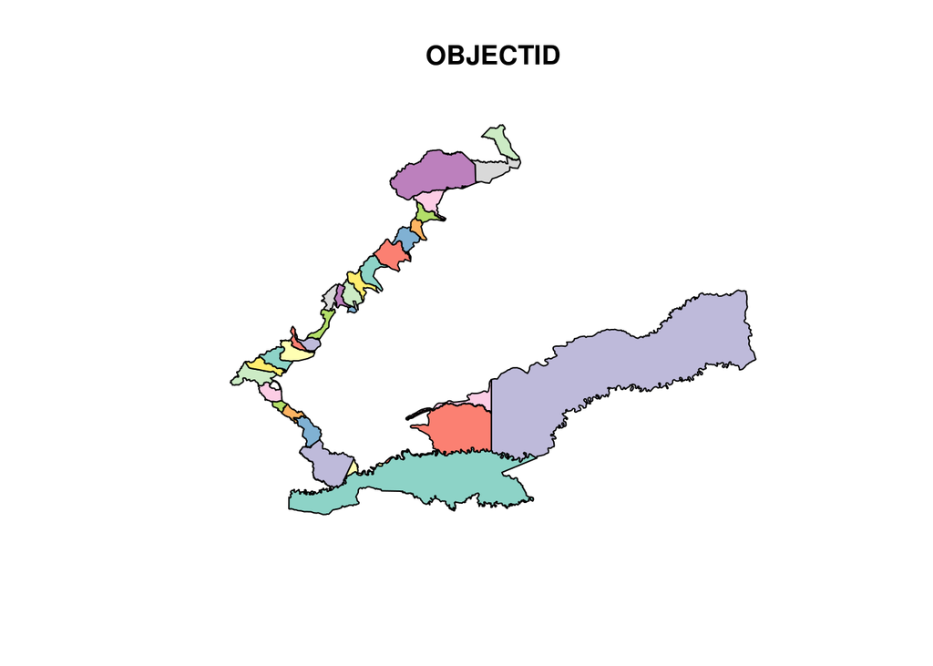

```r
plot(out[1])
```

Nota: Si al hacer una búsqueda los comandos de GRASS no aparecen entonces en QGIS ve al menu Processing - Options… - Providers - GRASS commands y chequea la casilla Activate. Por ejemplo al buscar “contour” salen resultados con GRASS, SAGA, y GDAL:

```r
find_algorithms("contour")
```

```
##  [1] "r.contour.level - Create vector contour from raster at specified levels--->grass7:r.contour.level"
##  [2] "r.contour.step - Create vector contours from raster at specified steps--->grass7:r.contour.step"
##  [3] "r.surf.contour - Surface generation program from rasterized contours.--->grass7:r.surf.contour"
##  [4] "v.lidar.growing - Building contour determination and Region Growing algorithm for determining the building inside--->grass7:v.lidar.growing"
##  [5] "Contour lines---------------------------------------->saga:contourlinesfromgrid"
##  [6] "Contour---------------------------------------------->gdalogr:contour"
##  [7] "r.contour.level - Create vector contour from raster at specified levels--->grass:r.contour.level"
##  [8] "r.contour.step - Create vector contours from raster at specified steps--->grass:r.contour.step"
##  [9] "r.surf.contour - Surface generation program from rasterized contours.--->grass:r.surf.contour"
## [10] "v.lidar.growing - Building contour determination and Region Growing algorithm for determining the building inside--->grass:v.lidar.growing"
```

Veamos los parámetros para ejecutar la función contour de GDAL:

```r
params <- get_args_man(alg = "gdalogr:contour")
params
```

```
## $INPUT_RASTER
## [1] "None"
##
## $INTERVAL
## [1] "10.0"
##
## $FIELD_NAME
## [1] "\"ELEV\""
##
## $EXTRA
## [1] "\"\""
##
## $OUTPUT_VECTOR
## [1] "None"
```

Definimos los parámetros de entrada y salida, ejecutamos la función y ploteamos el resultado:

```r
params$INPUT_RASTER  <- "data/AP_26958_FBS_F0060_RT2.dem.tif"
params$INTERVAL  <- 500
params$OUTPUT_VECTOR  <- file.path(tempdir(), "contours.shp")
contours <- run_qgis(alg = "gdalogr:contour", params = params, load_output = TRUE)
```

```
## $OUTPUT_VECTOR
## [1] "/tmp/RtmpTXsMU1/contours.shp"
```

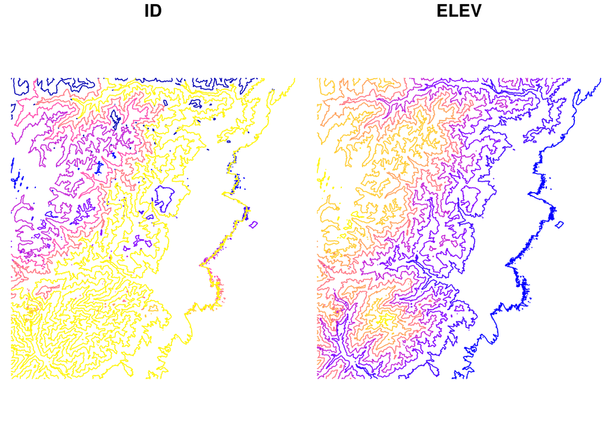

```r
plot(contours)
```

#### **b. pqgisr: Qgis from Python via rPython package**

**Instalación en Linux Lubuntu (Ubuntu)**

Primero instala en R algunas dependencias requeridas:

```r
install.packages(c("devtools", "pathological", "wkb", "base64enc"))
```

Luego instala rPython:

```r
install.packages("rPython")
```

Es posible que salga el siguiente error al intentar instalar rPython:

```
** package 'rPython' successfully unpacked and MD5 sums checked
a specific python version to use was not provided
defaulting to the standard python in the system
could not locate python-config
ERROR: configuration failed for package 'rPython'
* removing '/usr/local/lib/R/site-library/rPython'
```

En ese caso, abre una terminal de comandos en Linux y teclea la siguiente orden:

```
sudo apt-get install python-dev
```

y posteriormente reintenta la instalación de rPython:

```r
install.packages("rPython")
```

**Uso de pqgisr**

Usa `devtools::load_all` para cargar todo el paquete (pseudo-instalación y carga):

```r
setwd("~/shared/www/other/webinar/QGIS R/resources/pqgisr")
devtools::load_all("./pqgisr")
```

Ejecuta `init_qgis()` para iniciar una instancia de QGIS (puede que aparezcan algunos errores pero no deben impedir el funcionamiento):

```r
init_qgis()
```

Carga un mapa base y una capa vector desde archivo e inicia el canvas de QGIS:

```r
tiles <- add_tile_layer()
shp <- add_ogr_layer("data/llanos_latlon_col_v3.shp")
qgis
```

Remueve una capa y carga otra (nota la reproyección al vuelo):

```r
remove_layer(shp)
shp2 <- add_ogr_layer("data/mpios_llanos_col_v3_epsg3117_v1.shp")
qgis
```

Carga una capa vector desde un objeto de R (Spatial*DataFrame):

```r
library(raster)
spdf <- shapefile("data/cities.shp")
shp3 = add_sp_layer(spdf)
qgis
```

Carga archivos raster:

```r
rst = add_gdal_layer("data/mod11a1_2000_4.tif")
qgis
```

Remueve el raster y adiciona otro:

```r
remove_layer(rst)
rst2 = add_gdal_layer("data/c_2000_2001_1000m_epsg4326_clip_rec_2.rst")
qgis
```

#### **c. rqgisapi: R Interface to the QGIS Desktop Network API Plugin**

**Instalación en Linux Lubuntu (Ubuntu)**

1. En QGIS: se requiere instalar el plugin ‘Network API’ ([QGIS Desktop Network API and remote control plugin](https://gitlab.com/qgisapi/networkapi)) en la carpeta de plugins del usuario (e.g., /usr/share/qgis/python/plugins/). Para ello primero descarga el .zip desde https://gitlab.com/qgisapi/networkapi/repository/archive.zip?ref=master y descomprímelo (o clona el [repositorio de networkapi](https://gitlab.com/qgisapi/networkapi.git) alternativamente).

Nota: Para copiar un archivo en la carpeta de plugins de QGIS se necesita permisos de administrador, para lo cual una opción es utilizar *nautilus*:

```
sudo apt install nautilus
gksudo nautilus
```

Después de que hayas copiado el plugin ‘Network API’ en la carpeta de plugins, inicia QGIS (2.*) y activa el plugin en el menu Plugins - Manage and Install Plugins - ‘Network API’. Por defecto, la API se encuentra deshabilitada, por lo cual es necesario activarla chequeando la casilla de verificación de ‘Network API’ que se halla en la barra de estado en la parte inferior a la derecha en la ventana principal de QGIS.

2. Antes de ir a R es necesario instalar en el sistema operativo (Linux) las librerías v8 y udunits. En la terminal de comandos ingresa:

```
sudo apt-get install libv8-3.14-dev
sudo apt-get install libudunits2-dev
```

3. Luego en R, instala los paquetes V8 y udunits2 y verifica que la instalación haya sido exitosa:

```r
install.packages(c("V8", "udunits2"))
```

Instala otras dependencias requeridas:

```r
install.packages(c("geojsonio", "httr", "jsonlite", "raster", "rgdal", "settings", "sf", "sp"))
```

Finalmente instala rqgisapi desde su repositorio:

```r
devtools::install_git('https://gitlab.com/qgisapi/rqgisapi.git', quiet = FALSE)
```

**Uso de rqgisapi**

Con QGIS abierto y con el ‘Network API’ activado y habilitado, ya podemos hacer uso de rqgisapi. Carga el paquete e inspecciona la conexión por defecto:

```r
library(rqgisapi)
qgis_options('api')
```

Inicia un nuevo proyecto de QGIS:

```r
iface.newProject()
```

Carga capas al proyecto:

```r
iface.addVectorLayer('https://d2ad6b4ur7yvpq.cloudfront.net/naturalearth-3.3.0/ne_50m_populated_places.geojson', name = 'providerstring-layer')
```

Revisa algunas propiedades del proyecto:

```r
mapLayers.count()
mapCanvas.layerCount()
```

Extrae información de las capas:

```r
x <- mapLayers()
attributefeatures <- mapLayer.getFeatures(x[[1]])
class(attributefeatures$attributes)
colnames(attributefeatures$attributes)
```

Filtra elementos de las capas geográficamente:

```r
rectangle <- c(-85, -60, -27, 15)
layerdata <- mapLayer.getFeatures(x[[1]], rect = rectangle, geometry = TRUE)
class(layerdata)
plot(layerdata)
```

Manipula el canvas:

```r
mapCanvas.zoomToFullExtent()
```

```r
mapCanvas.center()
```

```r
mapCanvas.setCenter(0, 0)
```

```r
mapCanvas.extent()
mapCanvas.zoomIn()
mapCanvas.extent()
```

```r
mapCanvas.zoomOut()
```

Exporta el canvas como una imagen (objeto de clase RasterLayer):

```r
x <- mapCanvas.saveAsImage()
print(x)
raster::plotRGB(x)
```

### *Bonus*

#### **Integración de GRASS GIS y R**

Instala rgrass7 desde CRAN para trabajar con GRASS GIS 7 (o spgrass6 para GRASS GIS 6):

```r
install.packages("rgrass7")
```

En este ejemplo vamos a aplicar un filtro espacial a un raster de categorías. Primero importamos el raster a R y lo convertimos a SpatialGridDataFrame:

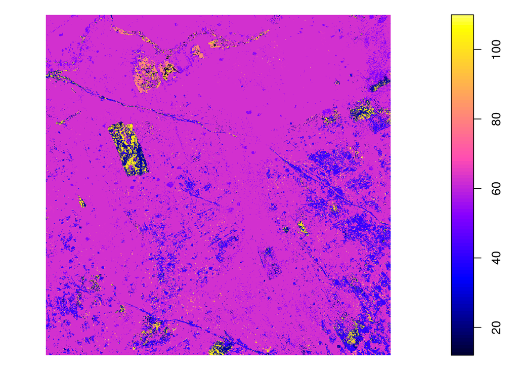

```r
library(raster)
img <- "data/pred_6100_0_0.tif"
r1 <- raster(img)
r2 <- as(r1, "SpatialGridDataFrame")
plot(r2)
```

Para iniciar GRASS GIS desde R cargamos el paquete rgrass7 y luego iniciamos una instancia de GRASS indicando la ruta donde está instalado. Acá utilizamos el raster importado para definir los parámetros de la locación en que vamos a trabajar. La instrucción en Linux sería la siguiente:

```r
library(rgrass7)
initGRASS("/usr/lib/grass72", home=tempdir(), SG = r2, override = TRUE)
```

```
## gisdbase    /tmp/RtmpTXsMU1
## location    file8c63fa7a67f
## mapset      file8c65f9b9cc5
## rows        837
## columns     848
## north       0
## south       -837
## west        0
## east        848
## nsres       1
## ewres       1
## projection  NA
```

De manera similar en Windows indicaríamos la ruta donde está instalado GRASS GIS:

```r
library(rgrass7)
initGRASS("C:/Program Files/GRASS GIS 7.0.3", home=tempdir(), SG = r2, override = TRUE)
```

Primero importamos la imagen .tif a la locación de trabajo:

```r
execGRASS("r.in.gdal", flags=c("o", "e"), parameters=list(input=img, output="r2"))
```

```
## WARNING: Over-riding projection check
## Proceeding with import of 1 raster bands...
## Importing raster map <r2>...
##    0%   3%   6%   9%  12%  15%  18%  21%  24%  27%  30%  33%  36%  39%  42%  45%  48%  51%  54%  57%  60%  63%  66%  69%  72%  75%  78%  81%  84%  87%  90%  93%  96%  99% 100%
## Region for the current mapset updated
```

Imprimimos la lista de capas raster o vector disponibles en la locación:

```r
execGRASS("g.list", parameters = list(type="all"))
```

```
## r2
```

Ejecutemos el módulo *r.neighbors* para aplicar un filtro de tipo *majority* donde la moda de los valores en una ventana de 11x11 pixels se asigna al pixel central:

```r
execGRASS("r.neighbors", parameters=list(input="r2", output="r2maj", method="mode", size=as.integer(11)))
```

```
##    0%   3%   6%   9%  12%  15%  18%  21%  24%  27%  30%  33%  36%  39%  42%  45%  48%  51%  54%  57%  60%  63%  66%  69%  72%  75%  78%  81%  84%  87%  90%  93%  96%  99% 100%
```

Veamos la lista de rasters en nuestra locación nuevamente, importemos el raster a R y ploteemos el resultado:

```r
execGRASS("g.list", parameters = list(type="all"))
```

```
## r2
## r2maj
```

```r
r2maj <- readRAST("r2maj")
```

```
## /tmp/RtmpTXsMU1/file8c63fa7a67f/file8c65f9b9cc5/cellhd/r2maj has GDAL driver GRASS
## and has 837 rows and 848 columns
```

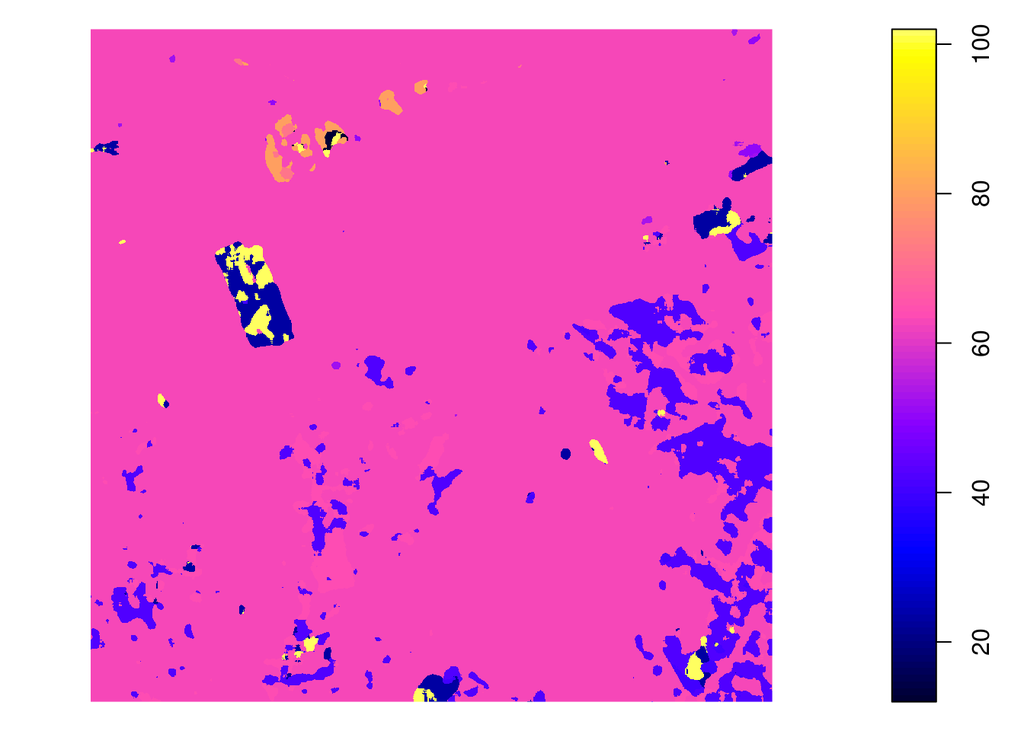

```r
plot(r2maj)
```

#### **Datos del tutorial**

Los datos, código fuente y diapositivas usados en este tutorial se pueden descargar desde [este link de Dropbox](https://www.dropbox.com/sh/97ggktfh0zd1ghk/AABSfUKbZmY9nH_iQwfb96Gpa?dl=0).

#### **[Ir al blog](http://amsantac.co/es/blog.html)**

Este documento fue generado con [RStudio IDE](https://www.rstudio.com/products/rstudio/download/) versión 1.0.143.